# Letter books - text mining

Alexander V. Christiansen

2025-05-12

Generally, the following code has been inspired by Max Odsbjergs St. Croix newspaper project, which operates with the same fundamental principles of assigning a tf-idf value to each term in the corpus. The project has been linked in the accompanying metadata file in github.

Activating libraries:

```r
library(tidyverse)
```

```r
library(tidytext)
library(ggwordcloud)
```

A dataframe is created from the csv:

```r
brevbøger_df <- read_csv("data/merged_brevbøger_1551-1660.csv")
```

(Strictly speaking, the creation of the csv was not necessary for running this code alone, but it makes reproducibility easier, as the csv-file is easily transferable. The below piece of code was, as an extension of this principle made for the purpose of reproducibility)

A new data frame is created, with the terms/words being split up into singular data points:

```r
brevbøger_df %>%
  unnest_tokens(word, Content) -> brevbøger_unnested
```

The words are counted:

```r
brevbøger_unnested %>%
  count(word, Year, sort = TRUE)
```

```
## # A tibble: 996,067 × 3
##    word   Year     n
##    <chr> <dbl> <int>
##  1 og     1653  6440
##  2 og     1650  6425
##  3 og     1657  6252
##  4 og     1647  6031
##  5 og     1656  5997
##  6 og     1645  5858
##  7 og     1655  5810
##  8 og     1646  5777
##  9 i      1634  5691
## 10 og     1658  5687
## # ℹ 996,057 more rows
```

Total number of words for each year is found, and a new data frame is created:

```r
brevbøger_unnested %>%
  count(word, Year) %>%
  group_by(Year) %>%
  summarise(total = sum(n)) -> total_words
```

A data frame is created, in which 4 variables are given; year, word, number of that word and total words:

```r
brevbøger_unnested %>%
  count(word,Year, sort = TRUE) %>%
  left_join(total_words, by = "Year") -> brevbøger_count
```

A new data frame is created where term frequency, inverse document frequency and tf-idf are new variables:

```r
brevbøger_count %>%
  bind_tf_idf(word, Year, n) -> brevbøger_tf_idf
```

THe terms are arranged in descending order by tf-idf:

```r
brevbøger_tf_idf %>%
  arrange(desc(tf_idf))
```

```
## # A tibble: 996,067 × 7
##    word   Year     n  total      tf   idf tf_idf
##    <chr> <dbl> <int>  <int>   <dbl> <dbl>  <dbl>
##  1 kbh    1659  2804 164392 0.0171   1.44 0.0246
##  2 kbh    1658  2800 179176 0.0156   1.44 0.0225
##  3 sjt    1659  1815 164392 0.0110   1.99 0.0220
##  4 kbh    1660  2287 160354 0.0143   1.44 0.0206
##  5 på     1647  1755 155334 0.0113   1.70 0.0193
##  6 sjt    1658  1607 179176 0.00897  1.99 0.0179
##  7 på     1646  1389 132817 0.0105   1.70 0.0178
##  8 på     1649  1301 127198 0.0102   1.70 0.0174
##  9 på     1648   996  97582 0.0102   1.70 0.0174
## 10 på     1650  1803 181144 0.00995  1.70 0.0170
## # ℹ 996,057 more rows
```

Using regex, all strictly numerical terms are filtered out, and a simple stopword list is created:

```r
custom_stopwords <- c("på", "miss", "sj", "rex", "subscr")

brevbøger_tf_idf_nnp <- brevbøger_tf_idf %>%
  filter(!grepl("^\\d+$", word) & !word %in% custom_stopwords)
```

Part of the above code has been created with the aid of ChatGPT

Terms are arranged in descending order in this data frame as well:

```r
brevbøger_tf_idf_nnp %>%
  arrange(desc(tf_idf))
```

```
## # A tibble: 935,358 × 7
##    word   Year     n  total      tf   idf tf_idf
##    <chr> <dbl> <int>  <int>   <dbl> <dbl>  <dbl>
##  1 kbh    1659  2804 164392 0.0171   1.44 0.0246
##  2 kbh    1658  2800 179176 0.0156   1.44 0.0225
##  3 sjt    1659  1815 164392 0.0110   1.99 0.0220
##  4 kbh    1660  2287 160354 0.0143   1.44 0.0206
##  5 sjt    1658  1607 179176 0.00897  1.99 0.0179
##  6 kbh    1657  2255 194425 0.0116   1.44 0.0167
##  7 kbh    1653  1910 175864 0.0109   1.44 0.0157
##  8 kbh    1651  1633 152646 0.0107   1.44 0.0154
##  9 sjt    1660  1228 160354 0.00766  1.99 0.0153
## 10 kbh    1649  1309 127198 0.0103   1.44 0.0148
## # ℹ 935,348 more rows
```

A decade range is defined, and a wordcloud is created for this decade range with the n(in this case set to 10) words with the highest tf-idf for each year is showcased, with the highest ones being violet and large and lowest being blue and smaller.

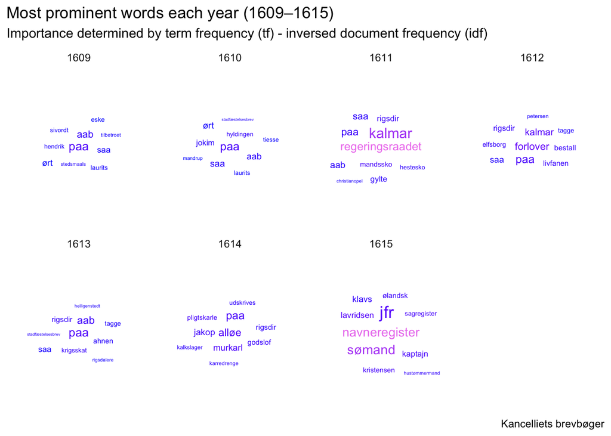

```r
start_year <- 1609
end_year <- 1615

brevbøger_tf_idf_nnp %>%
  filter(Year >= start_year, Year <= end_year) %>%
  arrange(desc(tf_idf)) %>%
  mutate(word = factor(word, levels = rev(unique(word)))) %>%
  group_by(Year) %>%
  slice_max(order_by = tf_idf, n = 10) %>%
  ungroup() %>%
  ggplot(aes(label = word, size = tf_idf, color = tf_idf)) +
  geom_text_wordcloud_area() +
  scale_size_area(max_size = 12) +
  theme_minimal() +
  facet_wrap(~Year, ncol = 4, scales = "free") +
  scale_color_gradient(low = "blue", high = "violet") +
  labs(
    title = paste0("Most prominent words each year (", start_year, "–", end_year, ")"),
    subtitle = "Importance determined by term frequency (tf) - inversed document frequency (idf)",
    caption = "Kancelliets brevbøger"
  )
```

Part of the above code has been sourced from Max Odsbjergs educational exercise about the St. Croix newspapers, but has subsequently been altered.